# POLSCI 672 Lab: Randomization Inference

## Randomization inference with `randomizr` and for-loops

Let us attempt Question 6 in the problem set. For purposes of demonstration, we will test a different sharp null hypothesis, $\tau_i = 0.25$. These steps apply generally for any sharp null.

It asks us to “generate 10,000 simulated random assignments under the sharp null hypothesis”. Let us do this step by step. We shall start by doing just 1 simulated random assignment.

### Step 1: Filling out potential outcomes

We need to first populate the potential outcomes, assuming the null hypothesis is true. If we were to do this by hand, we would first populate this based on the the observed potential outcomes. For some subject $i$, if $d_i = 0$, then the $Y_i$ in the experiment will be recorded as $Y_\text{null}^0$ for that subject. The same is done for $d_i = 1$ and $Y_\text{null}^1$.

Then, to fill the empty slots, we just make it such that $Y_\text{null}^1 - Y_\text{null}^0 = \tau_\text{null}$

There are a few ways to do this. For example, you may apply the switching equations:
$$Y_\text{null}^0 = (1 - d_i) Y_i + d_i (Y_i - \tau_\text{null}) \ \ \ \ \ \ Y_\text{null}^1 = d_i Y_i + (1 - d_i) (Y_i + \tau_\text{null})$$

Alternatively, we can use `case_when()` or `ifelse()`, which provide vectorized forms of if-else statements.

```r
# using switching equation
hajj_ri <-
  hajj %>%
  mutate(
    y0_null = (1 - success) * views + success * (views - 0.25),
    y1_null = success * views + (1 - success) * (views + 0.25)
  )

# using case_when
hajj_ri <-
  hajj %>%
  mutate(
    y0_null = case_when(
      success == 0 ~ views,
      success == 1 ~ views - 0.25
    ),
    y1_null = case_when(
      success == 1 ~ views,
      success == 0 ~ views + 0.25
    )
  )
```

If this step is done correctly, then $Y_\text{null}^1 - Y_\text{null}^0 = d_\text{null}$ must hold for all subjects.

```r
# preview data
hajj_ri %>%
  select(success, views, y0_null, y1_null) %>%
  head()
```

```
  success views y0_null y1_null
1       0     2       2    2.25
2       0     1       1    1.25
3       0     0       0    0.25
4       0     5       5    5.25
5       0     3       3    3.25
6       0     2       2    2.25
```

```r
# check if `y1_null - y0_null == .25` for each subject, then see if `TRUE` uniquely exists
unique(hajj_ri$y1_null - hajj_ri$y0_null == .25)
```

```
[1] TRUE
```

Remember, this first step of assigning potential outcomes under the null hypothesis is based on **actual** treatment assignment. This means that it does not change when we iterate over different hypothetical assignment vectors. Therefore, this step should be done outside the for-loop.

### Step 2: Simulate random assignment

The next step would be to simulate a random assignment. To do so, we should use the same random assignment procedure as the experiment conducted. Let us assign this to a new variable in the data (I will call it `d_temp`).

```r
# create random assignment vector
hajj_ri <-
  hajj_ri %>%
  mutate(d_temp = complete_ra(nrow(hajj_ri), sum(success)))

# check if random assignment is correct
sum(hajj_ri$success) == sum(hajj_ri$d_temp)
```

```
[1] TRUE
```

```r
# preview data
hajj_ri %>%
  select(success, views, y0_null, y1_null, d_temp) %>%
  head()
```

```
  success views y0_null y1_null d_temp
1       0     2       2    2.25      0
2       0     1       1    1.25      1
3       0     0       0    0.25      1
4       0     5       5    5.25      1
5       0     3       3    3.25      1
6       0     2       2    2.25      0
```

### Step 3: Extract observed outcomes under simulated random assignment

The `d_i` variable is now the random assignment vector we are working with. We should now create a variable (let us call it `y_temp`) of the observed outcomes under this random assignment. Similarly, this can be done using `case_when()` or the standard switching equation:

$$Y_i = d_i\cdot Y_i(1) + (1-d_i)\cdot Y_i(0)$$

```r
# using switching equation
hajj_ri <-
  hajj_ri %>%
  mutate(y_temp = d_temp * y1_null + (1 - d_temp) * y0_null)

# using case_when
hajj_ri <-
  hajj_ri %>%
  mutate(
    y_temp = case_when(
      d_temp == 0 ~ y0_null,
      d_temp == 1 ~ y1_null
    )
  )

# preview data
hajj_ri %>%
  select(success, views, y0_null, y1_null, d_temp, y_temp) %>%
  head()
```

```
  success views y0_null y1_null d_temp y_temp
1       0     2       2    2.25      0   2.00
2       0     1       1    1.25      1   1.25
3       0     0       0    0.25      1   0.25
4       0     5       5    5.25      1   5.25
5       0     3       3    3.25      1   3.25
6       0     2       2    2.25      0   2.00
```

### Step 4: Estimate ATE based on simulated random assignment

Now, given this simulated random assignment, we compute the DIM estimate. Again, there are a few ways to do this. You can simply take the mean of `y_temp` for the subset where `d_temp == 0` and subtract that from the mean of `y_temp` for the subset where `d_temp == 1`.

Alternatively, we can use the `estimatr` functions `difference_in_means()` or `lm_robust()`. Note that the coefficient for $d_i$ in $Y_i \sim d_i$ is equivalent to the DIM estimator.

```r
# using DIM function
sharp_null_dim <-
  hajj_ri %>%
  difference_in_means(y_temp ~ d_temp, .) %>%
  coefficients

# using lm_robust
sharp_null_dim <-
  hajj_ri %>%
  lm_robust(y_temp ~ d_temp, .) %>%
  coefficients %>%
  .[2]
```

**What in the pipe is going on here?**

The code here is essentially the same as what we did with `lm_robust()` last week, where the periods indicate where the LHS of the pipe should be inputted. This means I am calling `difference_in_means(y_temp ~ d_temp, hajj_ri)` or `lm_robust(y_temp ~ d_temp, hajj_ri)`.

Remember, however, that the outputs of these functions are not numbers or data frames, but instead are lists. Therefore, to get to the coefficients, we need to access the relevant item in the list. If you saved the output of the above functions to an object, you can see in the global environment that the list has an element `coefficients` which contains the estimate that we need. Therefore, we add an additional pipe to access `coefficients` and save that object instead.

Without pipes, the code to extract the difference in means is equivalent to:

```r
difference_in_means(y_temp ~ d_temp, hajj_ri)$coefficients
```

```
    d_temp
0.08069853
```

Note that when using `lm_robust()`, the `coefficients` vector contains a coefficient for the intercept and for `d_temp`. Since we only want the coefficient for `d_temp` here, I further subset to get only the second element in the vector.

We now have a DIM estimate! We need to produce this using 10,000 different treatment assignments, so we should run it in a for-loop. Try to form this for-loop yourself before reading on.

### Putting it all together

Have you made an attempt? Great! It is almost just as simple as placing everything in steps 2-4 in a for-loop that runs 10,000 times. The only change we must make is ensuring we get the correct output. When we did it for a single iteration, we got `sharp_null_dim` which contains a single DIM estimate. The output we wish to get from the for-loop should then be a vector with 10,000 DIM estimates. As when we discussed for-loops earlier, remember to format this last step correctly so that the output from previous iterations of the for-loop does not get overwritten.

```r
sharp_null_dim <- c()

hajj_ri <-
  hajj %>%
  mutate(
    y0_null = case_when(
      success == 0 ~ views,
      success == 1 ~ views - .25
    ),
    y1_null = case_when(
      success == 1 ~ views,
      success == 0 ~ views + .25
    )
  )

for (i in 1:10000) {
  hajj_ri <-
    hajj_ri %>%
    mutate(
      d_temp = complete_ra(nrow(hajj_ri), sum(success)),
      y_temp = case_when(
        d_temp == 0 ~ y0_null,
        d_temp == 1 ~ y1_null
      )
    )

  sharp_null_dim[i] <-
    hajj_ri %>%
    lm_robust(y_temp ~ d_temp, .) %>%
    coefficients %>%
    .[2]
}
```

If everything was done correctly, you should obtain a vector the same length as the number of simulations. This vector should contain the simulated ATE estimates that is distributed around a mean approximately equal to the expected value of the sharp null (which equals the sharp null itself).

```r
length(sharp_null_dim)
```

```
[1] 10000
```

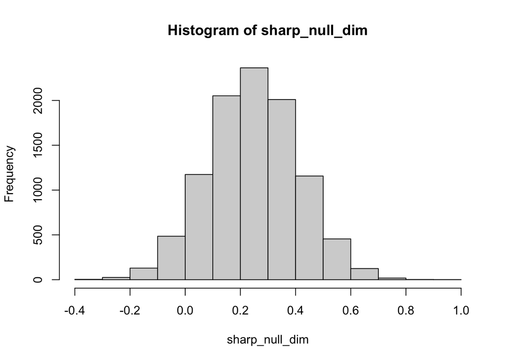

```r
hist(sharp_null_dim)
```

```r
mean(sharp_null_dim)
```

```
[1] 0.2482709
```

While it might be fine to run this exact code in the for-loop when the number of permutations is sufficiently large, it is preferable to extract random assignment vectors from the permutation matrix instead of running `complete_ra()` multiple times.

This is particularly the case when the number of possible permutations is equal to or fewer than 10,000 (or whatever maximum number of iterations we set). In such cases, `obtain_permutation_matrix()` will give us a matrix of all possible treatment assignment vectors, without repetition. Conducting random assignment in a for-loop, however, will result in duplicated treatment assignments.

```r
declaration <- declare_ra(nrow(hajj), m = sum(hajj$success))

D <- obtain_permutation_matrix(declaration)
```

Remember that the permutation matrix contains columns of treatment assignment vectors. Therefore, in the for-loop, you should assign as `d_temp` the 1st, 2nd, 3rd, … columns in the permutation matrix.

**Saving a few steps when the sharp null is $\tau_i = 0$**

As you are doing the problem set question where you test the sharp null of $\tau_i = 0$, you might realize that $Y_i^* = Y_i = Y_\text{null} (0) = Y_\text{null} (1)$. In such a case, you would be fine using the actual outcomes in place of the observed outcomes under simulated treatment. It is therefore actually possible to conduct randomization inference for Problem 6 using just one line of code in a for-loop.

### Calculating p-values

Now that we have the simulated distribution of DIMs, let us compute the DIM from the experiment and compare it with our simulated data.

```r
# compute DIM from actual experiment
hajj_dim <-
  hajj %>%
  difference_in_means(views ~ success, .) %>%
  coefficients

hajj_dim
```

```
  success
0.4748337
```

```r
# number of simulated DIM at least as large as actual
sum(sharp_null_dim >= hajj_dim)
```

```
[1] 830
```

```r
# one-sided p-value
mean(sharp_null_dim >= hajj_dim)
```

```
[1] 0.083
```

```r
# number of simulated DIM at least as large in absolute value as actual
sum(abs(sharp_null_dim) >= abs(hajj_dim))
```

```
[1] 830
```

```r
# two-sided p-value
mean(abs(sharp_null_dim) >= abs(hajj_dim))
```

```
[1] 0.083
```

Recall the definitions of p-values: the one-sided p-value is found by $\mathbb{P} (\theta \geq \hat{\theta})$ or $\mathbb{P} (\theta \leq \hat{\theta})$, while the two-sided p-value would be $\mathbb{P} (\lvert \theta \rvert \geq \lvert \hat{\theta} \rvert)$.

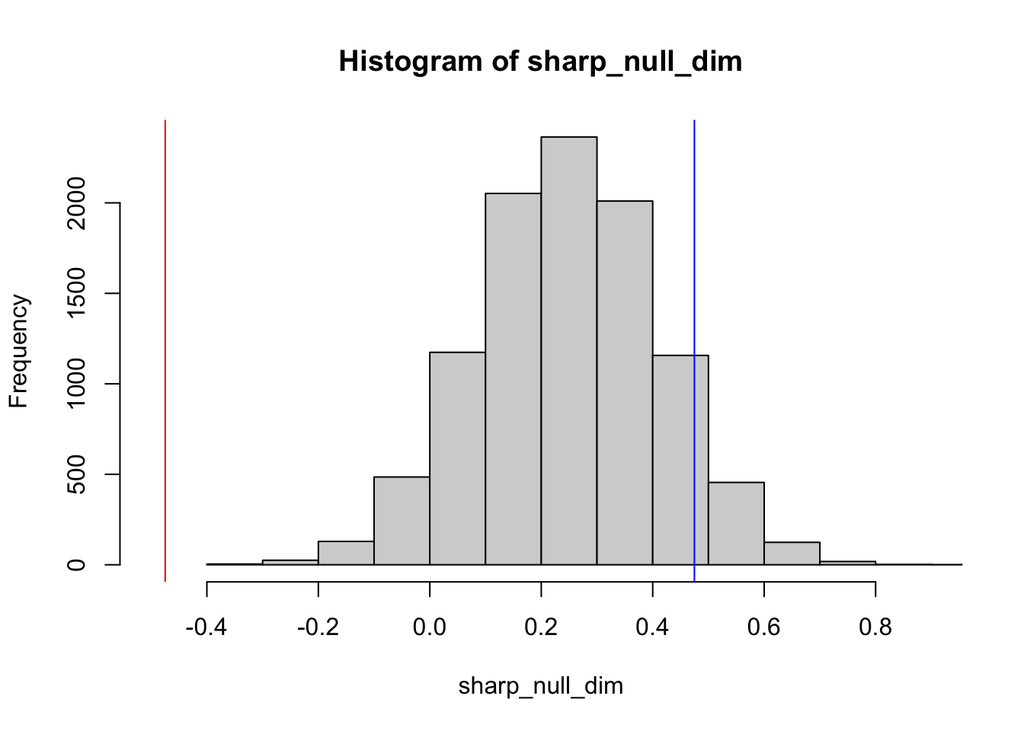

```r
hist(sharp_null_dim, xlim = c(- .5, .9))
abline(v = hajj_dim, col = "blue")
abline(v = - hajj_dim, col = "red")
```